# R 중급 통계분석 2일차 (4)

Sanghoo Yoon

# 다중회귀모형

다중회귀모형은 단순회귀모형에서 독립변수가 늘어난 경우

lm()함수에 독립변수만 추가해주시면 되므로 분석이 매우 용이

하지만 **다중공선성**과 **변수선택** (또는 모형선택)의 문제점이 있음

## 다중공선성

기억하시나요? 최소제곱법을 이용한 회귀계수 추정치는 다음과 같습니다.
$$\hat \beta = (X^T X)^{-1} X^T y$$

$\hat \beta$의 분산도 비슷한 식으로 계산됩니다.

$$Var (\hat \beta) = \sigma^2 (X^T
X)^{-1}$$

여기서 관심있게 봐야할 부분은 $(X^T X)^{-1}$ 입니다.

```r
data(airquality)
head(airquality)
```

```
##   Ozone Solar.R Wind Temp Month Day
## 1    41     190  7.4   67     5   1
## 2    36     118  8.0   72     5   2
## 3    12     149 12.6   74     5   3
## 4    18     313 11.5   62     5   4
## 5    NA      NA 14.3   56     5   5
## 6    28      NA 14.9   66     5   6
```

```r
reg.m <- lm(Ozone~Solar.R+Wind+Temp, data=airquality)
summary(reg.m)
```

```
##
## Call:
## lm(formula = Ozone ~ Solar.R + Wind + Temp, data = airquality)
##
## Residuals:
##     Min      1Q  Median      3Q     Max
## -40.485 -14.219  -3.551  10.097  95.619
##
## Coefficients:
##              Estimate Std. Error t value Pr(>|t|)
## (Intercept) -64.34208   23.05472  -2.791  0.00623 **
## Solar.R       0.05982    0.02319   2.580  0.01124 *
## Wind         -3.33359    0.65441  -5.094 1.52e-06 ***
## Temp          1.65209    0.25353   6.516 2.42e-09 ***
## ---
## Signif. codes:  0 '***' 0.001 '**' 0.01 '*' 0.05 '.' 0.1 ' ' 1
##
## Residual standard error: 21.18 on 107 degrees of freedom
##   (결측으로 인하여 42개의 관측치가 삭제되었습니다.)
## Multiple R-squared:  0.6059, Adjusted R-squared:  0.5948
## F-statistic: 54.83 on 3 and 107 DF,  p-value: < 2.2e-16
```

다중회귀모형을 통해 세워진 선형식은
$$Ozone =
-64.34+0.0598*Solar.R-3.3336*Wind+1.6521*Temp$$
이다.

여기서 회귀계수를 행렬식 $\hat \beta = (X^T X)^{-1} X^T y$을 이용해서 구해보자.

행렬을 이용하면 lm함수를 이용하지 않고도 회귀계수와 가설검정을 할 수 있다.

```r
comp.data <- airquality[complete.cases(airquality),] #결측치가 있어 제거

X <-cbind(rep(1, nrow(comp.data)),comp.data[,2:4]) # Design matrix
X <- as.matrix(X) # 행렬로 변환
head(X)
```

```
##   rep(1, nrow(comp.data)) Solar.R Wind Temp
## 1                       1     190  7.4   67
## 2                       1     118  8.0   72
## 3                       1     149 12.6   74
## 4                       1     313 11.5   62
## 7                       1     299  8.6   65
## 8                       1      99 13.8   59
```

```r
hat.beta<- solve(t(X)%*%X)%*%t(X)%*%comp.data[,1] # (X'X)^-1 X'y
round(hat.beta,3)
```

```
##                            [,1]
## rep(1, nrow(comp.data)) -64.342
## Solar.R                   0.060
## Wind                     -3.334
## Temp                      1.652
```

```r
se.beta<-sqrt(diag(solve(t(X)%*%X))*summary(reg.m)$sigma^2) # sigma (X'X)^-1
round(se.beta,3)
```

```
## rep(1, nrow(comp.data))                 Solar.R                    Wind
##                  23.055                   0.023                   0.654
##                    Temp
##                   0.254
```

```r
t.beta<-hat.beta/se.beta
round(t.beta,3)
```

```
##                           [,1]
## rep(1, nrow(comp.data)) -2.791
## Solar.R                  2.580
## Wind                    -5.094
## Temp                     6.516
```

```r
p.value<-2*(1-pt(abs(t.beta), df=nrow(comp.data)-4))
cbind(hat.beta, se.beta, t.beta, p.value)
```

```
##                                          se.beta
## rep(1, nrow(comp.data)) -64.34207893 23.05472435 -2.790841 6.226638e-03
## Solar.R                   0.05982059  0.02318647  2.579979 1.123664e-02
## Wind                     -3.33359131  0.65440710 -5.094063 1.515934e-06
## Temp                      1.65209291  0.25352979  6.516366 2.423506e-09
```

```r
summary(reg.m)
```

```
##
## Call:
## lm(formula = Ozone ~ Solar.R + Wind + Temp, data = airquality)
##
## Residuals:
##     Min      1Q  Median      3Q     Max
## -40.485 -14.219  -3.551  10.097  95.619
##
## Coefficients:
##              Estimate Std. Error t value Pr(>|t|)
## (Intercept) -64.34208   23.05472  -2.791  0.00623 **
## Solar.R       0.05982    0.02319   2.580  0.01124 *
## Wind         -3.33359    0.65441  -5.094 1.52e-06 ***
## Temp          1.65209    0.25353   6.516 2.42e-09 ***
## ---
## Signif. codes:  0 '***' 0.001 '**' 0.01 '*' 0.05 '.' 0.1 ' ' 1
##
## Residual standard error: 21.18 on 107 degrees of freedom
##   (결측으로 인하여 42개의 관측치가 삭제되었습니다.)
## Multiple R-squared:  0.6059, Adjusted R-squared:  0.5948
## F-statistic: 54.83 on 3 and 107 DF,  p-value: < 2.2e-16
```

여기서 X를 Design matrix라고 부르는데 X는 Intercept가 1이고, 나머지는 독립변수로 구성된 행렬이다.

설명변수 중 한 개가 다른 설명변수들의 선형조합읠 표현된다면 $X'X$가 특이한(singular) 상황이되어 *다중 공선성*을 갖게 된다.

이러한 경우 $(X'X)^{-1}$을 구할 수 없어 회귀계수 $\beta$에 대한 최소제곱추정량을 구하는데 문제가 발생하기 때문입니다.

예를 들어, 설명변수가 1개인 단순회귀모형의 $Var (\hat \beta_1)$는

$$Var(\hat \beta_1) = \hat \sigma^2 /
{\sum_{i=1}^n (X_i - \bar X)^2}$$
이다.

이를 설명변수가 2개인 다중회귀모형으로 확장시켜 $Var (\hat \beta_1)$과 $Var (\hat \beta_2)$를 구해보자.

$$Var (\hat \beta_j) = \sigma^2 ( {{1}
\over {1-r_{12}^2}})({{1}\over{\sum_{i=1}^n (X_{ij} - \bar
X_j)^2}})$$
여기서 ${{1} \over {1-r_{12}^2}}$ 안에 있는 $r_{12}$의 $X_1, X_2$의 상관계수이다.

만약 상관계수가 0이라면 1이되어 다중회귀모형과 단순회귀모형의 $Var (\hat \beta)$가 동일하다.

하지만 상관계수가 1에 가까워지면 $\frac{1}{1-r_{12}^2}$이 커져 $Var(\hat \beta_j)$가 커지게 된다.

다시말하면 독립변수 간 상관관계가 높을 경우 $\hat \beta_j$의 분산이 커지게 되므로 $VIF_i = \frac{1}{1-r_i^2}$를 분산팽창지수(Variance Inflation Factor)라고 한다.

일반적으로 10이 넘으면 다중공선성이 있다고 판단하며 5가 넘의면 주의할 필요가 있다고 판단한다.

```
Folklore says that V IFi > 10 indicates \serious" multicollinearity for the predictor.

I have been unable to discover who first proposed this threshold, or what the justification for it is.

It is also quite unclear what to do about this.

Large variance inflation factors do not, after all, violate any model assumptions.
```

독립변수 a와 b가 서로 상관 관계가 있다고 하면 두 변수 모두 VIF가 높다. 어느 하나만 VIF가 높은 경우는 없다.

VIF는 `car` 패키지의 `vif`함수를 이용하면 쉽게 계산된다.

```r
library(car)
vif(reg.m)
```

```
##  Solar.R     Wind     Temp
## 1.095253 1.329070 1.431367
```

vif 함수를 이용하지 않고 분산팽창지수를 구하려면?

airquality자료에 결측치가 있어 결측치를 제거한 자료가 comp.data이므로.

독립변수 간 선형모형을 구한 후 $\frac{1}{1-r_{12}^2}$에 대입하여 계산해보자.

```r
vif.1 <- lm(Solar.R~Wind+Temp, data=comp.data)
vif.2 <- lm(Wind~Solar.R+Temp, data=comp.data)
vif.3 <- lm(Temp~Wind+Solar.R, data=comp.data)

c(1/(1-summary(vif.1)$r.squared), 1/(1-summary(vif.2)$r.squared), 1/(1-summary(vif.3)$r.squared))
```

```
## [1] 1.095253 1.329070 1.431367
```

## 2. How to deal with a multicollinearity?

### Variable Selection

- 다중공선성이 높다고 판단된 변수들 중 몇 개를 제거한 후 분석 수행

### 주성분회귀분석

- 다변량 분석기법을 사용하여 서로 독립인 주성분을 생성 후 회귀분석 실시

### 정규화 선형회귀

정규화(regularized) 선형회귀 방법은 선형회귀 계수(weight)에 대한 제약 조건을 추가함으로써 모형이 과도하게 최적화되는 현상, 즉 과최적화를 막는 방법이다. Regularized Method, Penalized Method, Contrained Least Squares 이라고도 불리운다.

모형이 과도하게 최적화되면 모형 계수의 크기도 과도하게 증가하는 경향이 나타난다. 따라서 정규화 방법에서 추가하는 제약 조건은 일반적으로 계수의 크기를 제한하는 방법이다. 일반적으로 다음과 같은 세가지 방법이 사용된다.

- Ridge 회귀모형
- Lasso 회귀모형
- Elastic Net 회귀모형

#### Ridge 회귀모형

Ridge 회귀모형에서는 가중치들의 제곱합(squared sum of weights)을 최소화하는 것을 추가적인 제약 조건으로 한다.

$$w = \text{arg}\min_w \left(
\sum_{i=1}^N e_i^2 + \lambda \sum_{j=1}^M w_j^2 \right)$$

$\lambda$ 는 기존의 잔차 제곱합과 추가적 제약 조건의 비중을 조절하기 위한 하이퍼 모수(hyper parameter)이다. $\lambda$가 크면 정규화 정도가 커지고 가중치의 값들이 작아진다. $\lambda$가 작아지면 정규화 정도가 작아지며 $\lambda$ 가 0이 되면 일반적인 선형 회귀모형이 된다.

#### Lasso 회귀모형

Lasso(Least Absolute Shrinkage and Selection Operator) 회귀모형은 가중치의 절대값의 합을 최소화하는 것을 추가적인 제약 조건으로 한다.

$$w = \text{arg}\min_w \left(
\sum_{i=1}^N e_i^2 + \lambda \sum_{j=1}^M | w_j | \right)$$

여기서 $N$은 데이터 수, $i$는 데이터 인덱스, $j$는 예측변수의 인덱스, $\lambda$는 조율모수로 우측항(규제항)의 크기를 조절합니다. λ는 영(zero)일 때는 통상적인 최소제곱법의 결과와 동일하지만 $\lambda$가 커질수록 목적함수를 최소화하는 회귀계수는 더 작은값으로 축소되어 추정된다. 일반적으로 적절한 $\lambda$의 선택은 교차검증(Cross Validation) 등을 이용합니다. 라쏘회귀에서 사용하는 규제방식을 L1 규제(Penalty)라고 합니다.

라쏘 회귀분석의 제약조건에 따른 모수추정을 기하학적으로 나타내면 아래와 같습니다

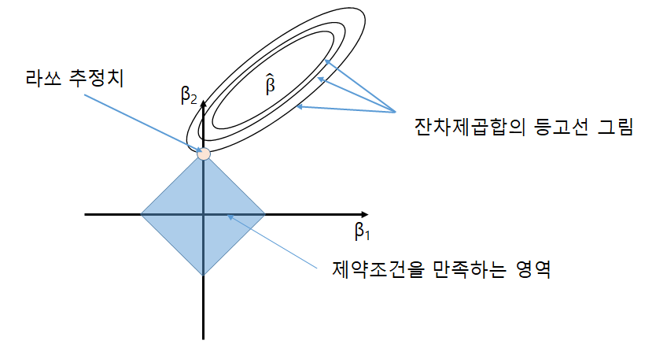

위에서 파란색의 사각형은 제약조건을 만족하는 영역이며 위의 타원형은 잔차제곱합의 등고선입니다. 이 잔차제곱합의 등고선과 제약조건을 만족하는 영역이 만나는 점이 라쏘회귀의 목적함수를 만족하는 회귀계수가 되겠습니다.

여기서 특기할 만한 점은 라쏘회귀분석의 회귀계수(β)는 0으로 추정할 수 있는 여지가 있어 자동적으로 변수선택 및 축소추정이 함께 이루어짐을 확인할 수 있습니다

#### Elastic Net 회귀모형

Elastic Net 회귀모형은 가중치의 절대값의 합과 제곱합을 동시에 제약 조건으로 가지는 모형이다.

$$w = \text{arg}\min_w \left(
\sum_{i=1}^N e_i^2 + \lambda_1 \sum_{j=1}^M | w_j | + \lambda_2
\sum_{j=1}^M w_j^2 \right)$$

$\lambda_1$, $\lambda_2$ 두 개의 하이퍼 모수를 가진다.

#### R에서

R에서 라쏘회귀분석 실시하기 : glmnet 패키지의 glmnet() 함수

R에서 라쏘회귀분석을 실시할 수 있는 함수는 glmnet패키지의 glmnet() 함수이며 입력인자는 다음과 같습니다.

glmnet() 패키지의 glmnet() 함수의 입력인자

x : 예측변수 (Matrix 형 데이터)

y : 반응변수(벡터형 데이터)

alpha : 0 : 릿지회귀분석, 1 : 라쏘회귀분석을 실시함.

그럼 R의 내장 데이터인 state.x77을 이용해 라쏘회귀분석을 실시하여 봅시다. 먼저 state.x77 데이터를 불러와 학습 및 테스트 비율을 8:2로 나눕니다.

```r
#데이터 불러오기
raw_data <- state.x77
head(raw_data)
```

```
##            Population Income Illiteracy Life Exp Murder HS Grad Frost   Area
## Alabama          3615   3624        2.1    69.05   15.1    41.3    20  50708
## Alaska            365   6315        1.5    69.31   11.3    66.7   152 566432
## Arizona          2212   4530        1.8    70.55    7.8    58.1    15 113417
## Arkansas         2110   3378        1.9    70.66   10.1    39.9    65  51945
## California      21198   5114        1.1    71.71   10.3    62.6    20 156361
## Colorado         2541   4884        0.7    72.06    6.8    63.9   166 103766
```

```r
#학습 및 테스트 데이터 나누기
 set.seed(100) #랜덤난수 초기값 고정
 trainIndex <- sample(1:nrow(raw_data),replace=F, size=40)
 train=raw_data[trainIndex, ] #학습용 데이터 80%
 test=raw_data[-trainIndex, ] #테스트용 데이터 20%
```

8개 변수 중 Life Exp(기대수명)을 종속변수로 두고 나머지 7개 변수는 예측변수로 나누어 각각 저장합니다. 이 때 예측변수는 scale() 함수를 이용해 표준화시킵니다.

```r
#학습 데이터 예측 및 종속변수 나누기
 train.x <- scale(train[,-4]) #예측변수 표준화
 train.y <- train[,4]

#테스트 데이터 예측 및 종속변수 나누기
 test.x <- scale(test[,-4]) #예측변수 표준화
 test.y <- test[,4]
```

그럼 학습데이터를 이용하여 라쏘회귀모델을 만들어 보도록 하겠습니다.

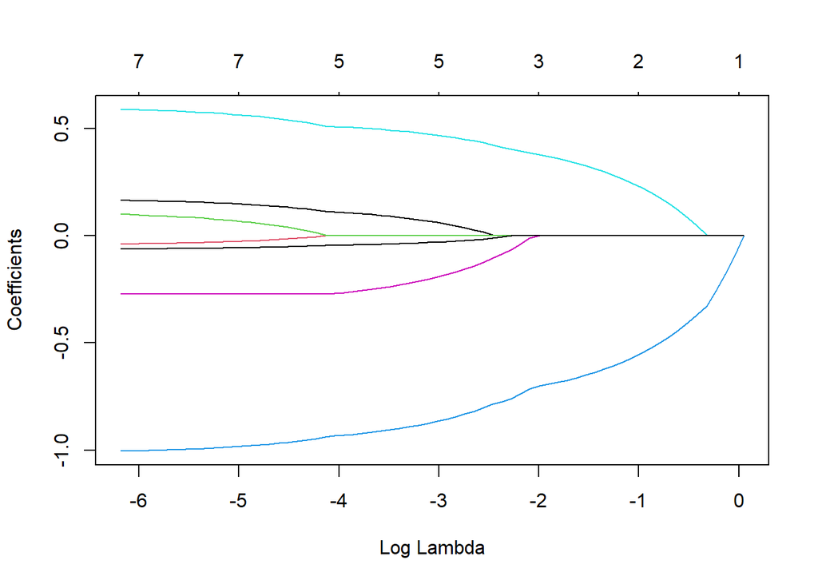

```r
library(glmnet)
lasso_model <- glmnet(train.x, train.y, alpha=1) #학습시키기
plot(lasso_model, xvar="lambda") #람다에 따른 회귀계수 확인하기
```

위에서 plot() 함수를 이용하면 λ (조율모수)에 따른 회귀계수의 추정치를 살펴볼 수 있습니다. 전체적으로 λ가 커질수록 회귀계수가 줄어듦을 확인할 수 있습니다. plot() 함수를 이용하면 각 변수의 회귀계수를 라벨링할 수 없어서 아래와 같이 모델결과 데이터를 이용하여 직접 처리해줍니다

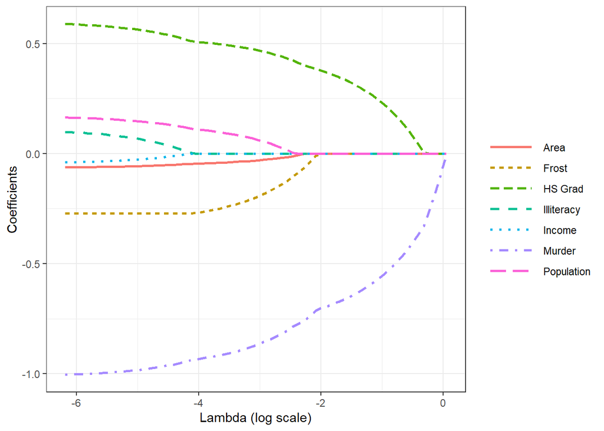

```r
#그래프를 그리기위한 데이터 처리
 beta=coef(lasso_model) #회귀계수 추출하기
 tmp <- as.data.frame(as.matrix(beta))
 tmp$coef <- row.names(tmp)
 tmp <- reshape::melt(tmp, id = "coef")
 tmp$variable <- as.numeric(gsub("s", "", tmp$variable))
 tmp$lambda <- log(lasso_model$lambda[tmp$variable+1]) # 람다 추출 및 log10변환
 tmp$norm <- apply(abs(beta[-1,]), 2, sum)[tmp$variable+1] # compute L1 norm

 #그래프 그리기
 library(ggplot2)
 ggplot(tmp[tmp$coef != "(Intercept)",], aes(lambda, value, color = coef, linetype = coef)) +
   geom_line(size=1) +
   xlab("Lambda (log scale)") +
   ylab("Coefficients") +
   guides(color = guide_legend(title = ""),
          linetype = guide_legend(title = "")) +
   theme_bw() +
   theme(legend.key.width = unit(3,"lines"))
```

다음으로 교차검증방법으로 적절한 λ을 선정합니다. 여기서 사용할 함수는 glmnet패키지의 cv.glmnet() 함수이며 glmnet() 함수와 같은 인자로 입력합니다. 교차검증방법 특성상 cv.glmnet() 함수를 실행할 때마다 결과가 바뀌기 때문에 set.seed() 함수로 난수를 고정시켜줍니다.

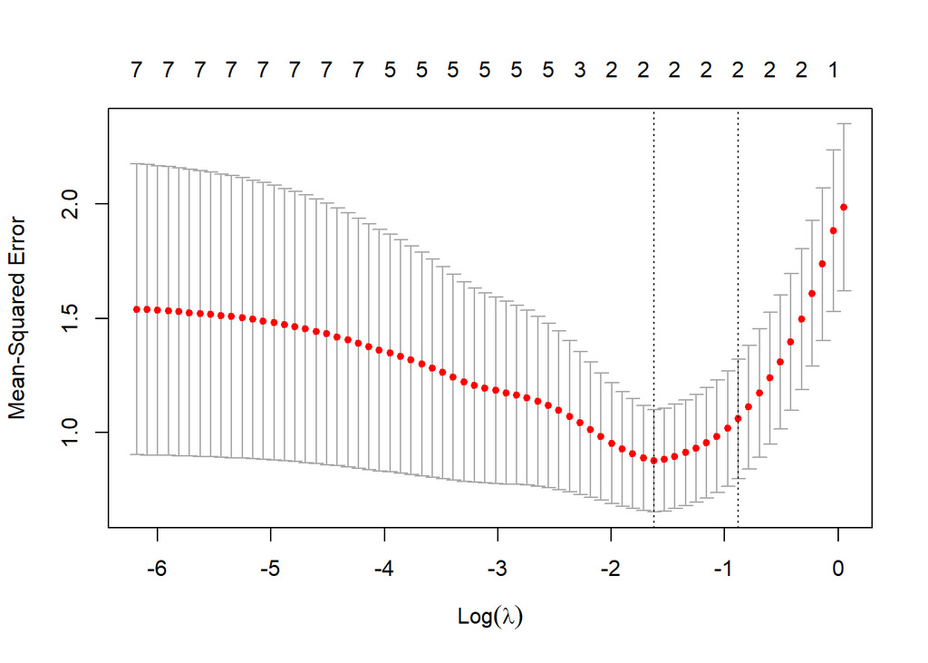

```r
 #교차검정을 통한 적절한 λ 선정
 set.seed(100) #초기값 고정
 cv.lasso <- cv.glmnet(train.x, train.y, alpha=1) #교차검정 실시
 plot(cv.lasso)
```

```r
 (best_lambda <- cv.lasso$lambda.min) #오차가 제일 작은 값(최적 λ)
```

```
## [1] 0.1970551
```

다음으로 적절한 λ를 다시 학습된 모델에 입력하여 각각 추정된 회귀계수를 추출해보도록 하겠습니다.

```r
#적절한 λ에 따른 회귀계수 확인
 (lasso_coef <- coef(lasso_model, s=best_lambda))
```

```
## 8 x 1 sparse Matrix of class "dgCMatrix"
##                     s1
## (Intercept) 70.9997500
## Population   .
## Income       .
## Illiteracy   .
## Murder      -0.6624622
## HS Grad      0.3376777
## Frost        .
## Area         .
```

마지막으로 테스트 데이터을 학습된 라쏘회귀모델에 입력하여 종속변수 Life.Exp를 예측해보도록 합시다. 사용할 함수는 predict() 함수입니다.

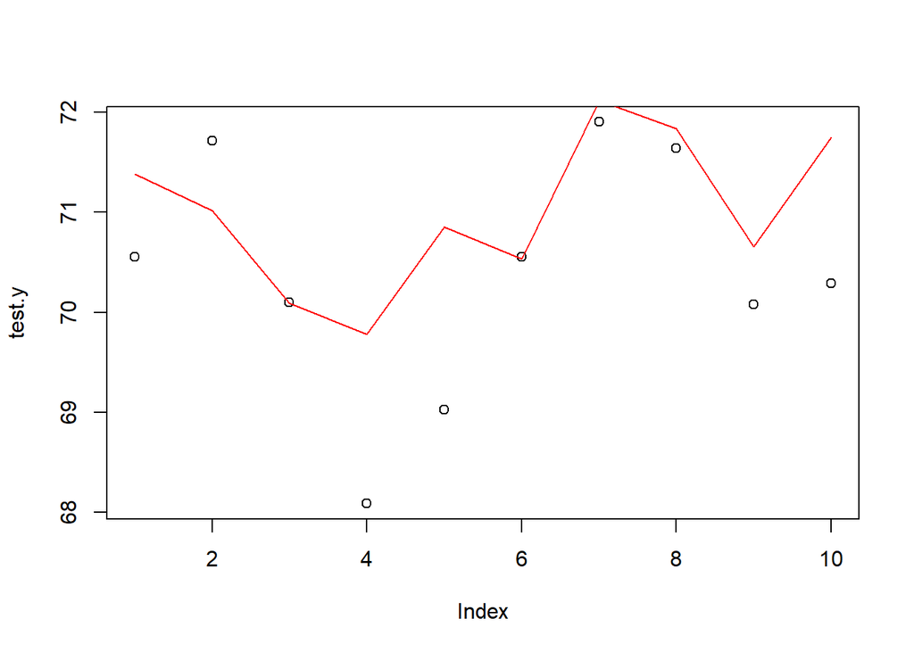

```r
# 라쏘회귀모형으로 예측하기
 pred_y <- predict(cv.lasso, newx=test.x, s="lambda.min")
 plot(test.y)
 lines(pred_y, col="red")
```

위에서 보듯 학습된 라쏘모형은 어느 정도 잘 적합됨을 확인할 수 있습니다.

## 최적 모형 선택 기준

> 1. 수정된 결정계수
> 2. AIC & BIC
> 3. Mallows cp

### R-Squared and Adj R-Squared

결정계수는 전체 분산 중 회귀모형이 얼마나 설명하는지를 나타내는 숫자입니다. 기억나나요?

그런데 $R^2$은 독립변수의 수가 증가할 수록 커지는 단점이 있습니다.

독립변수의 수가 늘어나더라도 모형의 결정계수가 증가하지 않는다면 추가된 독립변수는 모형에 영향력이 없는 변수 입니다.

이런 아이디어로 독립변수의 수가 늘어날수록 결정계수가 감소하도록 수정된 결정계수가 제안되었습니다.

$$R_{adj}^2 = 1- (1-R^2)
{{n-1}\over{n-q}}$$

### AIC와 BIC

최대우도법으로 회귀계수가 추정되면 AIC와 BIC를 기준으로 최적 모형을 선택할 수 있습니다.

AIC는 독립변수의 수가 고려되었고, BIC는 독립변수의 수에 자료의 수가 고려된 모형 선택 기준입니다.

AIC와 BIC는 작으면 작을수록 좋은 모형을 의미합니다.

회귀모형의 경우 최소제곱법과 최대우도법의 추정결과가 동일하므로 AIC와 BIC를 모형 선택 기준으로 사용할 수 있습니다.

### Mallows cp

Cp값은 조정된 R2과 AIC와 밀접한 관련이 있다.(최소제곱 모델에서만: Cp와 AIC는 비례한다.)

또한 Cp 값은 모든 변수가 다 포함 될 경우에 p값과 같게 된다.

따라서 나쁜 모델은 Cp값이 p값보다도 클 때이며 좋은 모델은 최소한 p값 보다 작을 때 이다.

## 변수선택

변수 들 중에서 불필요한 변수와 필요한 변수들을 선택하여 모델 선택

### 모든 가능한 조합

모든 가능한 조합에 대해 분석을 시행하는 방법

변수가 10개인 경우 $2^{10}=1024$번 회귀분석 실시

장점

- 가장 확실한 변수 선택
- 특정한 모형 선택 기준에 따라 좋은 축소 모형을 선택할 수 있음

단점

- 시간이 너무 오래 걸리므로 변수가 아주 적을 때 유용

leaps::regsubsets()함수는 2N개의 회귀 모형을 만들어 비교를 수행하는 함수

### R을 이용한 실습

```r
if(!require(mlbench)) install.pages("mlbench"); library(mlbench)
if(!require(leaps)) install.packages("leaps"); library(leaps)
data("BostonHousing")

m1 <- regsubsets(medv ~., data=BostonHousing)
summary(m1)
```

```
## Subset selection object
## Call: regsubsets.formula(medv ~ ., data = BostonHousing)
## 13 Variables  (and intercept)
##         Forced in Forced out
## crim        FALSE      FALSE
## zn          FALSE      FALSE
## indus       FALSE      FALSE
## chas1       FALSE      FALSE
## nox         FALSE      FALSE
## rm          FALSE      FALSE
## age         FALSE      FALSE
## dis         FALSE      FALSE
## rad         FALSE      FALSE
## tax         FALSE      FALSE
## ptratio     FALSE      FALSE
## b           FALSE      FALSE
## lstat       FALSE      FALSE
## 1 subsets of each size up to 8
## Selection Algorithm: exhaustive
##          crim zn  indus chas1 nox rm  age dis rad tax ptratio b   lstat
## 1  ( 1 ) " "  " " " "   " "   " " " " " " " " " " " " " "     " " "*"
## 2  ( 1 ) " "  " " " "   " "   " " "*" " " " " " " " " " "     " " "*"
## 3  ( 1 ) " "  " " " "   " "   " " "*" " " " " " " " " "*"     " " "*"
## 4  ( 1 ) " "  " " " "   " "   " " "*" " " "*" " " " " "*"     " " "*"
## 5  ( 1 ) " "  " " " "   " "   "*" "*" " " "*" " " " " "*"     " " "*"
## 6  ( 1 ) " "  " " " "   "*"   "*" "*" " " "*" " " " " "*"     " " "*"
## 7  ( 1 ) " "  " " " "   "*"   "*" "*" " " "*" " " " " "*"     "*" "*"
## 8  ( 1 ) " "  "*" " "   "*"   "*" "*" " " "*" " " " " "*"     "*" "*"
```

```r
summary(m1)$bic
```

```
## [1] -385.0521 -496.2582 -549.4767 -561.9884 -585.6823 -592.9553 -598.2295
## [8] -600.1663
```

```r
summary(m1)$adjr2
```

```
## [1] 0.5432418 0.6371245 0.6767036 0.6878351 0.7051702 0.7123567 0.7182560
## [8] 0.7222072
```

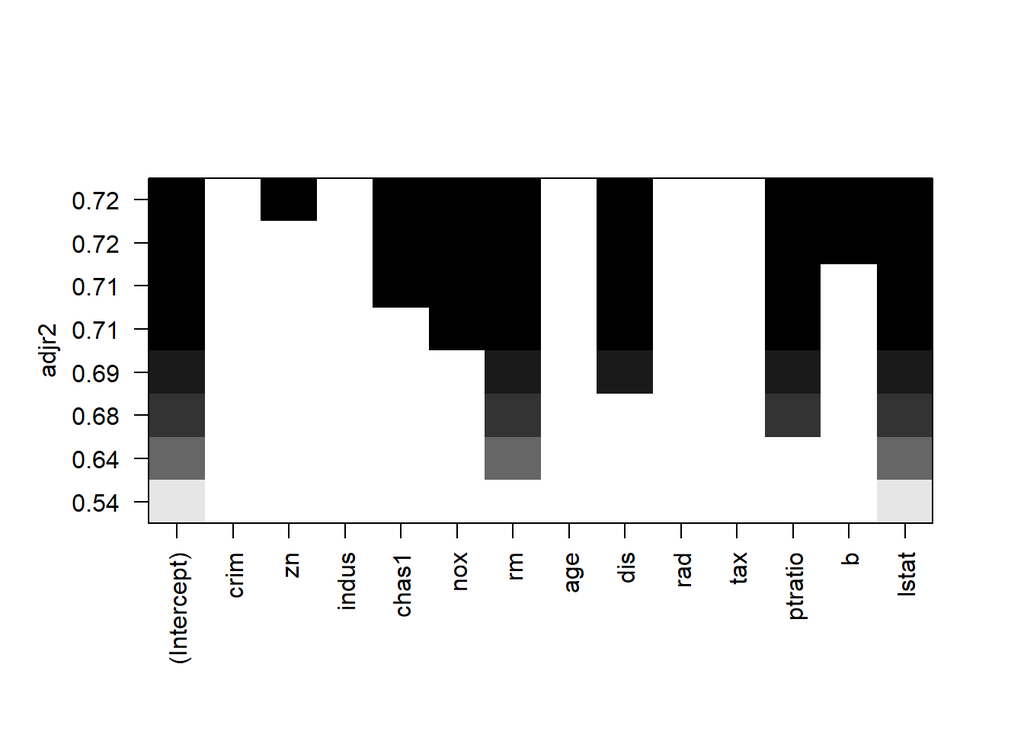

```r
plot(m1, scale="adjr2")
```

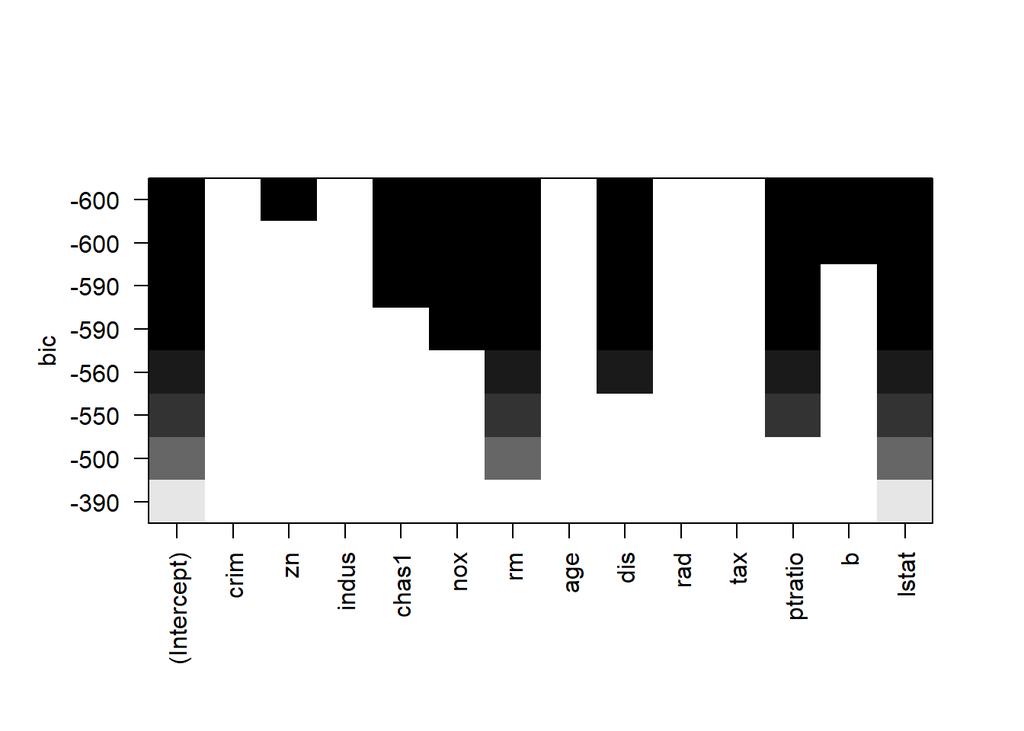

```r
plot(m1, scale="bic")
```

### 전진선택법

변수의 기여도를 평가하여 유의미하게 모형을 개선시키는 변수를 추가

단점 : 한번 선택된 변수는 절대로 제거되지 않음

알고리즘

1. 상수항만 포함된 모형
2. 기존의 모형과 변수가 하나 추가한 모형 중 모형 선택 기준을 통해 가장 좋은 모형 선택
3. 2에서 선택된 모형이 기존 모형이 아니면 2를 반복 수행, 만약 기존모형이면 변수 선택 중지

```r
model0 <- lm(medv ~1, data=BostonHousing)
add1(model0, scope = ~ crim + zn + indus + chas + nox + rm +
       age + dis + rad + tax + ptratio + b + lstat, test="F")
```

```
## Single term additions
##
## Model:
## medv ~ 1
##         Df Sum of Sq   RSS    AIC F value    Pr(>F)
## <none>               42716 2246.5
## crim     1    6440.8 36276 2165.8  89.486 < 2.2e-16 ***
## zn       1    5549.7 37167 2178.1  75.258 < 2.2e-16 ***
## indus    1    9995.2 32721 2113.6 153.955 < 2.2e-16 ***
## chas     1    1312.1 41404 2232.7  15.972 7.391e-05 ***
## nox      1    7800.1 34916 2146.5 112.591 < 2.2e-16 ***
## rm       1   20654.4 22062 1914.2 471.847 < 2.2e-16 ***
## age      1    6069.8 36647 2171.0  83.478 < 2.2e-16 ***
## dis      1    2668.2 40048 2215.9  33.580 1.207e-08 ***
## rad      1    6221.1 36495 2168.9  85.914 < 2.2e-16 ***
## tax      1    9377.3 33339 2123.1 141.761 < 2.2e-16 ***
## ptratio  1   11014.3 31702 2097.6 175.106 < 2.2e-16 ***
## b        1    4749.9 37966 2188.9  63.054 1.318e-14 ***
## lstat    1   23243.9 19472 1851.0 601.618 < 2.2e-16 ***
## ---
## Signif. codes:  0 '***' 0.001 '**' 0.01 '*' 0.05 '.' 0.1 ' ' 1
```

```r
model1 <- lm(medv ~lstat, data=BostonHousing)
add1(model1, scope = ~ crim + zn + indus + chas + nox + rm +
       age + dis + rad + tax + ptratio + b + lstat, test="F")
```

```
## Single term additions
##
## Model:
## medv ~ lstat
##         Df Sum of Sq   RSS    AIC  F value    Pr(>F)
## <none>               19472 1851.0
## crim     1     146.9 19325 1849.2   3.8246  0.051059 .
## zn       1     160.3 19312 1848.8   4.1758  0.041527 *
## indus    1      98.7 19374 1850.4   2.5635  0.109981
## chas     1     786.3 18686 1832.2  21.1665 5.336e-06 ***
## nox      1       4.8 19468 1852.9   0.1239  0.724966
## rm       1    4033.1 15439 1735.6 131.3942 < 2.2e-16 ***
## age      1     304.3 19168 1845.0   7.9840  0.004907 **
## dis      1     772.4 18700 1832.5  20.7764 6.488e-06 ***
## rad      1      25.1 19447 1852.4   0.6491  0.420799
## tax      1     274.4 19198 1845.8   7.1896  0.007574 **
## ptratio  1    2670.1 16802 1778.4  79.9340 < 2.2e-16 ***
## b        1     198.3 19274 1847.8   5.1764  0.023316 *
## ---
## Signif. codes:  0 '***' 0.001 '**' 0.01 '*' 0.05 '.' 0.1 ' ' 1
```

```r
model2 <- lm(medv ~lstat+rm, data=BostonHousing)
add1(model2, scope = ~ crim + zn + indus + chas + nox + rm +
       age + dis + rad + tax + ptratio + b + lstat, test="F")
```

```
## Single term additions
##
## Model:
## medv ~ lstat + rm
##         Df Sum of Sq   RSS    AIC F value    Pr(>F)
## <none>               15439 1735.6
## crim     1    311.42 15128 1727.3 10.3341 0.0013900 **
## zn       1     56.56 15383 1735.7  1.8457 0.1748999
## indus    1     61.09 15378 1735.6  1.9942 0.1585263
## chas     1    548.53 14891 1719.3 18.4921 2.051e-05 ***
## nox      1     14.90 15424 1737.1  0.4849 0.4865454
## age      1     20.18 15419 1736.9  0.6571 0.4179577
## dis      1    351.15 15088 1725.9 11.6832 0.0006819 ***
## rad      1    180.45 15259 1731.6  5.9367 0.0151752 *
## tax      1    425.16 15014 1723.5 14.2154 0.0001824 ***
## ptratio  1   1711.32 13728 1678.1 62.5791 1.645e-14 ***
## b        1    512.31 14927 1720.5 17.2290 3.892e-05 ***
## ---
## Signif. codes:  0 '***' 0.001 '**' 0.01 '*' 0.05 '.' 0.1 ' ' 1
```

```r
model3 <- lm(medv ~lstat+rm+ptratio, data=BostonHousing)
add1(model3, scope = ~ crim + zn + indus + chas + nox + rm +
       age + dis + rad + tax + ptratio + b + lstat, test="F")
```

```
## Single term additions
##
## Model:
## medv ~ lstat + rm + ptratio
##        Df Sum of Sq   RSS    AIC F value    Pr(>F)
## <none>              13728 1678.1
## crim    1    122.52 13606 1675.6  4.5115 0.0341560 *
## zn      1     14.96 13713 1679.6  0.5467 0.4600162
## indus   1      0.83 13727 1680.1  0.0301 0.8622688
## chas    1    377.96 13350 1666.0 14.1841 0.0001854 ***
## nox     1     24.81 13703 1679.2  0.9072 0.3413103
## age     1     66.24 13662 1677.7  2.4291 0.1197340
## dis     1    499.08 13229 1661.4 18.9009 1.668e-05 ***
## rad     1      6.07 13722 1679.9  0.2218 0.6378931
## tax     1     44.36 13684 1678.5  1.6242 0.2031029
## b       1    389.68 13338 1665.6 14.6369 0.0001468 ***
## ---
## Signif. codes:  0 '***' 0.001 '**' 0.01 '*' 0.05 '.' 0.1 ' ' 1
```

```r
model4 <- lm(medv ~lstat+rm+ptratio+dis, data=BostonHousing)
add1(model4, scope = ~ crim + zn + indus + chas + nox + rm +
       age + dis + rad + tax + ptratio + b + lstat, test="F")
```

```
## Single term additions
##
## Model:
## medv ~ lstat + rm + ptratio + dis
##        Df Sum of Sq   RSS    AIC F value    Pr(>F)
## <none>              13229 1661.4
## crim    1    233.54 12995 1654.4  8.9856  0.002857 **
## zn      1    144.81 13084 1657.8  5.5337  0.019040 *
## indus   1    242.65 12986 1654.0  9.3424  0.002359 **
## chas    1    267.43 12962 1653.1 10.3162  0.001404 **
## nox     1    759.56 12469 1633.5 30.4572 5.488e-08 ***
## age     1     61.36 13168 1661.0  2.3300  0.127535
## rad     1     22.40 13206 1662.5  0.8481  0.357540
## tax     1    240.34 12989 1654.1  9.2519  0.002476 **
## b       1    502.64 12726 1643.8 19.7482 1.089e-05 ***
## ---
## Signif. codes:  0 '***' 0.001 '**' 0.01 '*' 0.05 '.' 0.1 ' ' 1
```

```r
model5 <- lm(medv ~lstat+rm+ptratio+dis+nox, data=BostonHousing)
add1(model5, scope = ~ crim + zn + indus + chas + nox + rm +
       age + dis + rad + tax + ptratio + b + lstat, test="F")
```

```
## Single term additions
##
## Model:
## medv ~ lstat + rm + ptratio + dis + nox
##        Df Sum of Sq   RSS    AIC F value    Pr(>F)
## <none>              12469 1633.5
## crim    1    141.43 12328 1629.7  5.7248 0.0170955 *
## zn      1    151.71 12318 1629.3  6.1461 0.0134998 *
## indus   1     17.10 12452 1634.8  0.6854 0.4081212
## chas    1    328.27 12141 1622.0 13.4920 0.0002655 ***
## age     1      0.25 12469 1635.5  0.0098 0.9211095
## rad     1     53.48 12416 1633.3  2.1494 0.1432543
## tax     1     10.50 12459 1635.0  0.4205 0.5169877
## b       1    311.83 12158 1622.7 12.7991 0.0003806 ***
## ---
## Signif. codes:  0 '***' 0.001 '**' 0.01 '*' 0.05 '.' 0.1 ' ' 1
```

```r
model6 <- lm(medv ~lstat+rm+ptratio+dis+nox+chas, data=BostonHousing)
add1(model6, scope = ~ crim + zn + indus + chas + nox + rm +
       age + dis + rad + tax + ptratio + b + lstat, test="F")
```

```
## Single term additions
##
## Model:
## medv ~ lstat + rm + ptratio + dis + nox + chas
##        Df Sum of Sq   RSS    AIC F value    Pr(>F)
## <none>              12141 1622.0
## crim    1   116.330 12025 1619.1  4.8178 0.0286287 *
## zn      1   164.406 11977 1617.1  6.8361 0.0092038 **
## indus   1    26.274 12115 1622.9  1.0800 0.2991938
## age     1     2.331 12139 1623.9  0.0956 0.7572505
## rad     1    58.556 12082 1621.5  2.4135 0.1209286
## tax     1     4.187 12137 1623.8  0.1718 0.6786847
## b       1   272.837 11868 1612.5 11.4484 0.0007719 ***
## ---
## Signif. codes:  0 '***' 0.001 '**' 0.01 '*' 0.05 '.' 0.1 ' ' 1
```

```r
model7 <- lm(medv ~lstat+rm+ptratio+dis+nox+chas+b, data=BostonHousing)
add1(model7, scope = ~ crim + zn + indus + chas + nox + rm +
       age + dis + rad + tax + ptratio + b + lstat, test="F")
```

```
## Single term additions
##
## Model:
## medv ~ lstat + rm + ptratio + dis + nox + chas + b
##        Df Sum of Sq   RSS    AIC F value   Pr(>F)
## <none>              11868 1612.5
## crim    1    55.633 11813 1612.1  2.3407 0.126671
## zn      1   189.936 11678 1606.3  8.0832 0.004652 **
## indus   1    15.584 11853 1613.8  0.6535 0.419264
## age     1     9.446 11859 1614.1  0.3959 0.529516
## rad     1   144.320 11724 1608.3  6.1180 0.013714 *
## tax     1     2.703 11866 1614.4  0.1132 0.736643
## ---
## Signif. codes:  0 '***' 0.001 '**' 0.01 '*' 0.05 '.' 0.1 ' ' 1
```

```r
model8 <- lm(medv ~lstat+rm+ptratio+dis+nox+chas+b+zn, data=BostonHousing)
add1(model8, scope = ~ crim + zn + indus + chas + nox + rm +
       age + dis + rad + tax + ptratio + b + lstat, test="F")
```

```
## Single term additions
##
## Model:
## medv ~ lstat + rm + ptratio + dis + nox + chas + b + zn
##        Df Sum of Sq   RSS    AIC F value  Pr(>F)
## <none>              11678 1606.3
## crim    1    94.712 11584 1604.2  4.0555 0.04457 *
## indus   1    16.048 11662 1607.6  0.6825 0.40912
## age     1     1.491 11677 1608.2  0.0633 0.80138
## rad     1    93.614 11585 1604.2  4.0081 0.04583 *
## tax     1     3.952 11674 1608.1  0.1679 0.68215
## ---
## Signif. codes:  0 '***' 0.001 '**' 0.01 '*' 0.05 '.' 0.1 ' ' 1
```

```r
model9 <- lm(medv ~lstat+rm+ptratio+dis+nox+chas+b+zn+crim, data=BostonHousing)
add1(model9, scope = ~ crim + zn + indus + chas + nox + rm +
       age + dis + rad + tax + ptratio + b + lstat, test="F")
```

```
## Single term additions
##
## Model:
## medv ~ lstat + rm + ptratio + dis + nox + chas + b + zn + crim
##        Df Sum of Sq   RSS    AIC F value   Pr(>F)
## <none>              11584 1604.2
## indus   1    15.773 11568 1605.5  0.6750 0.411725
## age     1     2.470 11581 1606.1  0.1056 0.745387
## rad     1   228.604 11355 1596.1  9.9656 0.001692 **
## tax     1     1.305 11582 1606.1  0.0558 0.813396
## ---
## Signif. codes:  0 '***' 0.001 '**' 0.01 '*' 0.05 '.' 0.1 ' ' 1
```

```r
model10 <- lm(medv ~lstat+rm+ptratio+dis+nox+chas+b+zn+crim+rad, data=BostonHousing)
add1(model10, scope = ~ crim + zn + indus + chas + nox + rm +
       age + dis + rad + tax + ptratio + b + lstat, test="F")
```

```
## Single term additions
##
## Model:
## medv ~ lstat + rm + ptratio + dis + nox + chas + b + zn + crim +
##     rad
##        Df Sum of Sq   RSS    AIC F value    Pr(>F)
## <none>              11355 1596.1
## indus   1    33.894 11321 1596.6  1.4790 0.2245162
## age     1     0.096 11355 1598.1  0.0042 0.9485270
## tax     1   273.619 11081 1585.8 12.1978 0.0005214 ***
## ---
## Signif. codes:  0 '***' 0.001 '**' 0.01 '*' 0.05 '.' 0.1 ' ' 1
```

```r
model11 <- lm(medv ~lstat+rm+ptratio+dis+nox+chas+b+zn+crim+rad+tax, data=BostonHousing)
add1(model11, scope = ~ crim + zn + indus + chas + nox + rm +
       age + dis + rad + tax + ptratio + b + lstat, test="F")
```

```
## Single term additions
##
## Model:
## medv ~ lstat + rm + ptratio + dis + nox + chas + b + zn + crim +
##     rad + tax
##        Df Sum of Sq   RSS    AIC F value Pr(>F)
## <none>              11081 1585.8
## indus   1   2.51754 11079 1587.7  0.1120 0.7380
## age     1   0.06271 11081 1587.8  0.0028 0.9579
```

쉽게 사용하는 방법은??

```r
m2 <- step(lm(medv~1, BostonHousing), scope = ~ crim + zn + indus + chas + nox + rm +
       age + dis + rad + tax + ptratio + b + lstat,direction="forward")
```

```
## Start:  AIC=2246.51
## medv ~ 1
##
##           Df Sum of Sq   RSS    AIC
## + lstat    1   23243.9 19472 1851.0
## + rm       1   20654.4 22062 1914.2
## + ptratio  1   11014.3 31702 2097.6
## + indus    1    9995.2 32721 2113.6
## + tax      1    9377.3 33339 2123.1
## + nox      1    7800.1 34916 2146.5
## + crim     1    6440.8 36276 2165.8
## + rad      1    6221.1 36495 2168.9
## + age      1    6069.8 36647 2171.0
## + zn       1    5549.7 37167 2178.1
## + b        1    4749.9 37966 2188.9
## + dis      1    2668.2 40048 2215.9
## + chas     1    1312.1 41404 2232.7
## <none>                 42716 2246.5
##
## Step:  AIC=1851.01
## medv ~ lstat
##
##           Df Sum of Sq   RSS    AIC
## + rm       1    4033.1 15439 1735.6
## + ptratio  1    2670.1 16802 1778.4
## + chas     1     786.3 18686 1832.2
## + dis      1     772.4 18700 1832.5
## + age      1     304.3 19168 1845.0
## + tax      1     274.4 19198 1845.8
## + b        1     198.3 19274 1847.8
## + zn       1     160.3 19312 1848.8
## + crim     1     146.9 19325 1849.2
## + indus    1      98.7 19374 1850.4
## <none>                 19472 1851.0
## + rad      1      25.1 19447 1852.4
## + nox      1       4.8 19468 1852.9
##
## Step:  AIC=1735.58
## medv ~ lstat + rm
##
```

[output cut: 108 more lines]

```
##
##         Df Sum of Sq   RSS    AIC
## + tax    1   273.619 11081 1585.8
## <none>               11355 1596.1
## + indus  1    33.894 11321 1596.6
## + age    1     0.096 11355 1598.1
##
## Step:  AIC=1585.76
## medv ~ lstat + rm + ptratio + dis + nox + chas + b + zn + crim +
##     rad + tax
##
##         Df Sum of Sq   RSS    AIC
## <none>               11081 1585.8
## + indus  1   2.51754 11079 1587.7
## + age    1   0.06271 11081 1587.8
```

```r
summary(m2)
```

```
##
## Call:
## lm(formula = medv ~ lstat + rm + ptratio + dis + nox + chas +
##     b + zn + crim + rad + tax, data = BostonHousing)
##
## Residuals:
##      Min       1Q   Median       3Q      Max
## -15.5984  -2.7386  -0.5046   1.7273  26.2373
##
## Coefficients:
##               Estimate Std. Error t value Pr(>|t|)
## (Intercept)  36.341145   5.067492   7.171 2.73e-12 ***
## lstat        -0.522553   0.047424 -11.019  < 2e-16 ***
## rm            3.801579   0.406316   9.356  < 2e-16 ***
## ptratio      -0.946525   0.129066  -7.334 9.24e-13 ***
## dis          -1.492711   0.185731  -8.037 6.84e-15 ***
## nox         -17.376023   3.535243  -4.915 1.21e-06 ***
## chas1         2.718716   0.854240   3.183 0.001551 **
## b             0.009291   0.002674   3.475 0.000557 ***
## zn            0.045845   0.013523   3.390 0.000754 ***
## crim         -0.108413   0.032779  -3.307 0.001010 **
## rad           0.299608   0.063402   4.726 3.00e-06 ***
## tax          -0.011778   0.003372  -3.493 0.000521 ***
## ---
## Signif. codes:  0 '***' 0.001 '**' 0.01 '*' 0.05 '.' 0.1 ' ' 1
##
## Residual standard error: 4.736 on 494 degrees of freedom
## Multiple R-squared:  0.7406, Adjusted R-squared:  0.7348
## F-statistic: 128.2 on 11 and 494 DF,  p-value: < 2.2e-16
```

### 후진제거법

모든 변수가 포함되어 있는 모형에서 변수를 하나씩 제거해 가며 변수를 선택하는 방법

단점 : 유의미하지 않는 변수가 포함될 수 있음

알고리즘

1. 모든 변수가 포함된 모형
2. 기존의 모형과 변수가 하나 제거된 모형 중 모형 선택 기준을 통해 좋은 모형 선택
3. 기존의 모형과 변수가 하나 제거된 모형 간 차이가 없을 경우 변수 제거,

   만약 기존의 모형과 변수가 제거된 모형 간 유의미한 차이가 있으면 변수 선택 중지

```r
model0 <- lm(medv ~., data=BostonHousing)
drop1(model0, scope = ~ crim + zn + indus + chas + nox + rm +
       age + dis + rad + tax + ptratio + b + lstat, test="F")
```

```
## Single term deletions
##
## Model:
## medv ~ crim + zn + indus + chas + nox + rm + age + dis + rad +
##     tax + ptratio + b + lstat
##         Df Sum of Sq   RSS    AIC  F value    Pr(>F)
## <none>               11079 1589.6
## crim     1    243.22 11322 1598.6  10.8012 0.0010868 **
## zn       1    257.49 11336 1599.3  11.4351 0.0007781 ***
## indus    1      2.52 11081 1587.8   0.1118 0.7382881
## chas     1    218.97 11298 1597.5   9.7243 0.0019250 **
## nox      1    487.16 11566 1609.4  21.6342 4.246e-06 ***
## rm       1   1871.32 12950 1666.6  83.1040 < 2.2e-16 ***
## age      1      0.06 11079 1587.7   0.0027 0.9582293
## dis      1   1232.41 12311 1641.0  54.7305 6.013e-13 ***
## rad      1    479.15 11558 1609.1  21.2788 5.071e-06 ***
## tax      1    242.26 11321 1598.6  10.7585 0.0011116 **
## ptratio  1   1194.23 12273 1639.4  53.0350 1.309e-12 ***
## b        1    270.63 11349 1599.8  12.0187 0.0005729 ***
## lstat    1   2410.84 13490 1687.3 107.0634 < 2.2e-16 ***
## ---
## Signif. codes:  0 '***' 0.001 '**' 0.01 '*' 0.05 '.' 0.1 ' ' 1
```

```r
model1 <- lm(medv ~.-age, data=BostonHousing)
drop1(model1, scope = ~ crim + zn + indus + chas + nox + rm +
       dis + rad + tax + ptratio + b + lstat, test="F")
```

```
## Single term deletions
##
## Model:
## medv ~ (crim + zn + indus + chas + nox + rm + age + dis + rad +
##     tax + ptratio + b + lstat) - age
##         Df Sum of Sq   RSS    AIC  F value    Pr(>F)
## <none>               11079 1587.7
## crim     1    243.20 11322 1596.6  10.8221 0.0010747 **
## zn       1    260.32 11339 1597.4  11.5841 0.0007194 ***
## indus    1      2.52 11081 1585.8   0.1120 0.7379887
## chas     1    219.91 11299 1595.6   9.7859 0.0018626 **
## nox      1    520.87 11600 1608.9  23.1781 1.967e-06 ***
## rm       1   1959.55 13038 1668.0  87.1987 < 2.2e-16 ***
## dis      1   1352.26 12431 1643.9  60.1743 5.028e-14 ***
## rad      1    481.09 11560 1607.2  21.4083 4.751e-06 ***
## tax      1    242.24 11321 1596.6  10.7796 0.0010991 **
## ptratio  1   1200.23 12279 1637.7  53.4092 1.099e-12 ***
## b        1    272.26 11351 1597.9  12.1154 0.0005445 ***
## lstat    1   2718.88 13798 1696.7 120.9879 < 2.2e-16 ***
## ---
## Signif. codes:  0 '***' 0.001 '**' 0.01 '*' 0.05 '.' 0.1 ' ' 1
```

```r
model2 <- lm(medv ~.-age-indus, data=BostonHousing)
drop1(model2, scope = ~ crim + zn + chas + nox + rm +
       dis + rad + tax + ptratio + b + lstat, test="F")
```

```
## Single term deletions
##
## Model:
## medv ~ (crim + zn + indus + chas + nox + rm + age + dis + rad +
##     tax + ptratio + b + lstat) - age - indus
##         Df Sum of Sq   RSS    AIC F value    Pr(>F)
## <none>               11081 1585.8
## crim     1    245.37 11327 1594.8  10.939 0.0010104 **
## zn       1    257.82 11339 1595.4  11.494 0.0007543 ***
## chas     1    227.21 11309 1594.0  10.129 0.0015515 **
## nox      1    541.91 11623 1607.9  24.158 1.209e-06 ***
## rm       1   1963.66 13045 1666.3  87.539 < 2.2e-16 ***
## dis      1   1448.94 12530 1645.9  64.593 6.837e-15 ***
## rad      1    500.92 11582 1606.1  22.331 2.997e-06 ***
## tax      1    273.62 11355 1596.1  12.198 0.0005214 ***
## ptratio  1   1206.45 12288 1636.0  53.783 9.235e-13 ***
## b        1    270.82 11352 1596.0  12.073 0.0005566 ***
## lstat    1   2723.48 13805 1695.0 121.411 < 2.2e-16 ***
## ---
## Signif. codes:  0 '***' 0.001 '**' 0.01 '*' 0.05 '.' 0.1 ' ' 1
```

```r
m3 <- step(lm(medv~., BostonHousing), direction="backward")
```

```
## Start:  AIC=1589.64
## medv ~ crim + zn + indus + chas + nox + rm + age + dis + rad +
##     tax + ptratio + b + lstat
##
##           Df Sum of Sq   RSS    AIC
## - age      1      0.06 11079 1587.7
## - indus    1      2.52 11081 1587.8
## <none>                 11079 1589.6
## - chas     1    218.97 11298 1597.5
## - tax      1    242.26 11321 1598.6
## - crim     1    243.22 11322 1598.6
## - zn       1    257.49 11336 1599.3
## - b        1    270.63 11349 1599.8
## - rad      1    479.15 11558 1609.1
## - nox      1    487.16 11566 1609.4
## - ptratio  1   1194.23 12273 1639.4
## - dis      1   1232.41 12311 1641.0
## - rm       1   1871.32 12950 1666.6
## - lstat    1   2410.84 13490 1687.3
##
## Step:  AIC=1587.65
## medv ~ crim + zn + indus + chas + nox + rm + dis + rad + tax +
##     ptratio + b + lstat
##
##           Df Sum of Sq   RSS    AIC
## - indus    1      2.52 11081 1585.8
## <none>                 11079 1587.7
## - chas     1    219.91 11299 1595.6
## - tax      1    242.24 11321 1596.6
## - crim     1    243.20 11322 1596.6
## - zn       1    260.32 11339 1597.4
## - b        1    272.26 11351 1597.9
## - rad      1    481.09 11560 1607.2
## - nox      1    520.87 11600 1608.9
## - ptratio  1   1200.23 12279 1637.7
## - dis      1   1352.26 12431 1643.9
## - rm       1   1959.55 13038 1668.0
## - lstat    1   2718.88 13798 1696.7
##
## Step:  AIC=1585.76
## medv ~ crim + zn + chas + nox + rm + dis + rad + tax + ptratio +
##     b + lstat
##
##           Df Sum of Sq   RSS    AIC
## <none>                 11081 1585.8
## - chas     1    227.21 11309 1594.0
## - crim     1    245.37 11327 1594.8
## - zn       1    257.82 11339 1595.4
## - b        1    270.82 11352 1596.0
## - tax      1    273.62 11355 1596.1
## - rad      1    500.92 11582 1606.1
## - nox      1    541.91 11623 1607.9
## - ptratio  1   1206.45 12288 1636.0
## - dis      1   1448.94 12530 1645.9
## - rm       1   1963.66 13045 1666.3
## - lstat    1   2723.48 13805 1695.0
```

```r
summary(m2)
```

```
##
## Call:
## lm(formula = medv ~ lstat + rm + ptratio + dis + nox + chas +
##     b + zn + crim + rad + tax, data = BostonHousing)
##
## Residuals:
##      Min       1Q   Median       3Q      Max
## -15.5984  -2.7386  -0.5046   1.7273  26.2373
##
## Coefficients:
##               Estimate Std. Error t value Pr(>|t|)
## (Intercept)  36.341145   5.067492   7.171 2.73e-12 ***
## lstat        -0.522553   0.047424 -11.019  < 2e-16 ***
## rm            3.801579   0.406316   9.356  < 2e-16 ***
## ptratio      -0.946525   0.129066  -7.334 9.24e-13 ***
## dis          -1.492711   0.185731  -8.037 6.84e-15 ***
## nox         -17.376023   3.535243  -4.915 1.21e-06 ***
## chas1         2.718716   0.854240   3.183 0.001551 **
## b             0.009291   0.002674   3.475 0.000557 ***
## zn            0.045845   0.013523   3.390 0.000754 ***
## crim         -0.108413   0.032779  -3.307 0.001010 **
## rad           0.299608   0.063402   4.726 3.00e-06 ***
## tax          -0.011778   0.003372  -3.493 0.000521 ***
## ---
## Signif. codes:  0 '***' 0.001 '**' 0.01 '*' 0.05 '.' 0.1 ' ' 1
##
## Residual standard error: 4.736 on 494 degrees of freedom
## Multiple R-squared:  0.7406, Adjusted R-squared:  0.7348
## F-statistic: 128.2 on 11 and 494 DF,  p-value: < 2.2e-16
```

### 단계적 방법

전진선택법과 후진제거법이 모두 고려된 방법

```r
m4 <- step(lm(medv~., BostonHousing), direction="both")
```

```
## Start:  AIC=1589.64
## medv ~ crim + zn + indus + chas + nox + rm + age + dis + rad +
##     tax + ptratio + b + lstat
##
##           Df Sum of Sq   RSS    AIC
## - age      1      0.06 11079 1587.7
## - indus    1      2.52 11081 1587.8
## <none>                 11079 1589.6
## - chas     1    218.97 11298 1597.5
## - tax      1    242.26 11321 1598.6
## - crim     1    243.22 11322 1598.6
## - zn       1    257.49 11336 1599.3
## - b        1    270.63 11349 1599.8
## - rad      1    479.15 11558 1609.1
## - nox      1    487.16 11566 1609.4
## - ptratio  1   1194.23 12273 1639.4
## - dis      1   1232.41 12311 1641.0
## - rm       1   1871.32 12950 1666.6
## - lstat    1   2410.84 13490 1687.3
##
## Step:  AIC=1587.65
## medv ~ crim + zn + indus + chas + nox + rm + dis + rad + tax +
##     ptratio + b + lstat
##
##           Df Sum of Sq   RSS    AIC
## - indus    1      2.52 11081 1585.8
## <none>                 11079 1587.7
## + age      1      0.06 11079 1589.6
## - chas     1    219.91 11299 1595.6
## - tax      1    242.24 11321 1596.6
## - crim     1    243.20 11322 1596.6
## - zn       1    260.32 11339 1597.4
## - b        1    272.26 11351 1597.9
## - rad      1    481.09 11560 1607.2
## - nox      1    520.87 11600 1608.9
## - ptratio  1   1200.23 12279 1637.7
## - dis      1   1352.26 12431 1643.9
## - rm       1   1959.55 13038 1668.0
## - lstat    1   2718.88 13798 1696.7
##
## Step:  AIC=1585.76
## medv ~ crim + zn + chas + nox + rm + dis + rad + tax + ptratio +
##     b + lstat
##
##           Df Sum of Sq   RSS    AIC
## <none>                 11081 1585.8
## + indus    1      2.52 11079 1587.7
## + age      1      0.06 11081 1587.8
## - chas     1    227.21 11309 1594.0
## - crim     1    245.37 11327 1594.8
## - zn       1    257.82 11339 1595.4
## - b        1    270.82 11352 1596.0
## - tax      1    273.62 11355 1596.1
## - rad      1    500.92 11582 1606.1
## - nox      1    541.91 11623 1607.9
## - ptratio  1   1206.45 12288 1636.0
## - dis      1   1448.94 12530 1645.9
## - rm       1   1963.66 13045 1666.3
## - lstat    1   2723.48 13805 1695.0
```

```r
summary(m4)
```

```
##
## Call:
## lm(formula = medv ~ crim + zn + chas + nox + rm + dis + rad +
##     tax + ptratio + b + lstat, data = BostonHousing)
##
## Residuals:
##      Min       1Q   Median       3Q      Max
## -15.5984  -2.7386  -0.5046   1.7273  26.2373
##
## Coefficients:
##               Estimate Std. Error t value Pr(>|t|)
## (Intercept)  36.341145   5.067492   7.171 2.73e-12 ***
## crim         -0.108413   0.032779  -3.307 0.001010 **
## zn            0.045845   0.013523   3.390 0.000754 ***
## chas1         2.718716   0.854240   3.183 0.001551 **
## nox         -17.376023   3.535243  -4.915 1.21e-06 ***
## rm            3.801579   0.406316   9.356  < 2e-16 ***
## dis          -1.492711   0.185731  -8.037 6.84e-15 ***
## rad           0.299608   0.063402   4.726 3.00e-06 ***
## tax          -0.011778   0.003372  -3.493 0.000521 ***
## ptratio      -0.946525   0.129066  -7.334 9.24e-13 ***
## b             0.009291   0.002674   3.475 0.000557 ***
## lstat        -0.522553   0.047424 -11.019  < 2e-16 ***
## ---
## Signif. codes:  0 '***' 0.001 '**' 0.01 '*' 0.05 '.' 0.1 ' ' 1
##
## Residual standard error: 4.736 on 494 degrees of freedom
## Multiple R-squared:  0.7406, Adjusted R-squared:  0.7348
## F-statistic: 128.2 on 11 and 494 DF,  p-value: < 2.2e-16
```

### 모형 선택기준

수정결정계수 adj R^2

- 결정계수의 결점을 보완하기 위하여 제시된 방법으로 변수의 수만큼 패널티 부여
- 모형의 간명성과 설명력을 동시에 고려할 수 있어 널리 사용됨

Mellows $C_p$

- 예측식이 가지는 수행능력을 예측값에 대한 MSE를 고려한 방법
- $C_{p} = p+1$이 가장 좋은 모형

AIC
$$AIC = -2 \log L(MLE) +
2(p+1)$$
- 정확도와 간명성을 상충하는 방법

- 많은 변수를 갖는 모형에 패널티 부여
- 작으면 작을 수록 좋음

BIC
$$IBC=n \log \left( {{SSE_{p}} \over
{n}} \right) + p( \log_{n} )$$

- AIC가 과정합 되는 경향을 자료수를 고려하여 제어
- AIC에 비해 복잡한 모형에 더 큰 패널티 부여
- 작으면 작을수록 좋음